# IGF1R-3QQU - Calx-β Molecular Dynamics with Gromacs

Load and interactively visualize files in `../data/3d_struct/` with **nglview**, then (optional) run a **GROMACS** binding-site MD simulation of **calx-β** on **IGF1R (3QQU)**.

**Input Files:**

| File | Contents |
| --- | --- |
| 3QQU.pdbqs | IGF1R kinase receptor (AutoDock grid map source) |
| calxbeta_18.39.pdb | Calx-β docked to IGF1R (−18.39 kcal/mol) |

**Not used here yet:**

| File | Contents |
| --- | --- |
| `IVM_3qqu_mid_17.25.pdb` | Ivermectin docked pose, run 13 (−17.25 kcal/mol) |
| `IVM_17.45_3QQU.pdb` | Ivermectin docked pose, run 11 (−17.45 kcal/mol) |

**Run in the MD container** (`./up-md.sh --build` from `tomo_2026b/md/`).

```
Structure folder: /workspace/repos/tomo_2026b/md/data/3d_struct
Found 4 file(s)
```

|  | file | suffix | n_atoms | n_models | docked_energy_kcal_mol | warnings |
| --- | --- | --- | --- | --- | --- | --- |
| 0 | 3QQU.pdbqs | .pdbqs | 2702 | 1 | NaN | Truncating .pdbqs ATOM records to 80-column PD... |
| 1 | IVM_17.45_3QQU.pdb | .pdb | 65 | 1 | -17.45 | RTF wrapper detected — extracting ATOM/MODEL r... |
| 2 | IVM_3qqu_mid_17.25.pdb | .pdb | 65 | 1 | -17.25 |  |
| 3 | calxbeta_18.39.pdb | .pdb | 1190 | 1 | NaN |  |

## Structures

Each panel is one file from `data/3d_struct/`. Large receptors use **cartoon**; docked ligands use **ball+stick**.

**3QQU.pdbqs**

```
note: Truncating .pdbqs ATOM records to 80-column PDB for nglview
atoms=2702  models=1
```

```
NGLWidget()
```

**calxbeta_18.39.pdb**

```
atoms=1190  models=1
```

```
NGLWidget()
```

**This notebook is set for a 30 ns production run** (`TOTAL_STEPS = 15_000_000` at 2 fs). Production `mdrun` uses GPU offload (`-nb gpu -pme gpu -bonded gpu -update gpu`) when `USE_GPU_MDRUN = True` — run the kernel in the CUDA image (`./md-run.sh --gpu`). Equilibration (EM/NVT/NPT) runs on CPU `mdrun` under `data/md_calx_3qqu/` (gcsfuse). **Production** `grompp` + `mdrun` run under **`/tmp/md_calx_3qqu/`** (local disk); outputs are copied back to `data/md_calx_3qqu/` when the run finishes (and after each checkpoint write).

### Why `/tmp` for production

The workspace path is backed by **gcsfuse**. Long production runs write large, frequent files (`md.xtc`, `md.cpt`, `md.edr`, `md.log`). On gcsfuse these writes are slow and can block the Jupyter kernel (sometimes seen as `KeyboardInterrupt` during VM teardown). Local `/tmp` avoids that I/O path for the hours-long production step.

### Checkpoints every 1 ns (`nstcheckpoint = 500000`)

At `dt = 0.002` ps (2 fs), 1 ns = 1000 ps → **500000 steps** between checkpoint writes. GROMACS keeps a single `md.cpt` file and overwrites it each time; the default interval (~15 min wall time, ~40k steps) caused too many gcsfuse writes when production ran on the workspace. With production on `/tmp`, checkpoints still use a 1 ns interval so a VM loss loses at most ~1 ns of simulation time.

**Re-grompp for a new checkpoint interval:** `nstcheckpoint` is stored in `md.tpr` at `grompp` time. Editing `md.mdp` alone does not change an existing `md.tpr`. To use the 1 ns interval, re-run production `grompp` (pipeline step 7) before the next `mdrun`. You can still resume from an existing `md.cpt` with `-cpi md.cpt`; only the *future* checkpoint schedule comes from the new `.tpr`.

### Must re-run helper cells after any notebook sync

Jupyter keeps **old function bodies in the kernel** until you re-execute them. After pulling/syncing this file into `/workspace`, **re-run the MD setup cells** that define `sync_md_to_tmp` / `run_gmx` / `production_mdrun_args` / `run_md_pipeline` (the cells under this section) **before** the `RUN_MD` pipeline cell. Confirm the helper printout mentions `/tmp/md_calx_3qqu`.

Verbose GROMACS stdout is written under **`/tmp`** during long runs, with progress milestones only in the notebook; the log is copied into `data/runs/` when the pipeline finishes.

**Session idle / teardown:** If the launch UI shows "Idle timeout very soon" / remaining `0:00`, the VM may tear down soon and the kernel will raise `KeyboardInterrupt` even while `mdrun` is progressing. Extend idle time from the session control bar and confirm remaining time is non-zero before starting a multi-hour production run.

### Re-entrant `RUN_MD` (automatic resume)

When **`data/md_calx_3qqu/md.cpt`** exists in the workspace (GCS via gcsfuse), re-run the helper cells and the **`RUN_MD` cell** — it **does not** repeat solvation, EM, NVT, or NPT. It:

1. Copies the latest checkpoint and matching inputs from workspace → **`/tmp/md_calx_3qqu/`**
2. Runs production `mdrun` with **`-cpi md.cpt`** on local disk (GPU flags when enabled)
3. Copies **`md.cpt` back to the workspace after each checkpoint write** (~every 1 ns), then full outputs at the end

Set **`FORCE_FROM_SCRATCH = True`** in the config cell to ignore an existing checkpoint and run the full pipeline from solvation.

**Do not re-run production `grompp` on resume** — that would restart from NPT coordinates instead of the checkpoint. Resume uses the existing **`md.tpr`** paired with **`md.cpt`**. To change `nstcheckpoint` after a run has started, finish or discard the run and start fresh with `FORCE_FROM_SCRATCH = True`.

```
complex: /workspace/repos/tomo_2026b/md/data/md_calx_3qqu/complex_calx_3qqu.pdb  atoms=3892
skipped single-residue fragments: D:ARG1061, I:GLU1115, K:ILE1202, L:LEU1205
pocket: /workspace/repos/tomo_2026b/md/data/md_calx_3qqu/pocket_calx_3qqu.pdb  atoms=1743 residues=180 chains=9 (receptor=598, calx-β=1190, cutoff=1.0 nm)
```

```
NGLWidget()
```

```
MDP files: ions.mdp, em.mdp, nvt.mdp, npt.mdp, md.mdp | EM 5,000  NVT/NPT 25,000  production 15,000,000 steps
RE-RUN OK: production uses /tmp/md_calx_3qqu (local disk). Checkpoints every 500,000 steps (1000 ps). When md.cpt exists in workspace, RUN_MD resumes production only (no equilibration).
```

```
RE-RUN OK: production_mdrun_args() runs under /tmp/md_calx_3qqu with -cpi md.cpt when present. Confirm Idle time remaining > 0 before long mdrun.
```

```
Live run log (local /tmp): /tmp/md_calx_3qqu_20260817_090759.log
Will copy to workspace at end: /workspace/repos/tomo_2026b/md/data/runs/md_calx_3qqu_20260817_090759.log
Run log (live /tmp): /tmp/md_calx_3qqu_20260817_090759.log
=== Resuming GROMACS production from workspace checkpoint ===
Synced 34 file(s) → /tmp/md_calx_3qqu (production mdrun uses local disk, not gcsfuse)
Resuming production from /workspace/repos/tomo_2026b/md/data/md_calx_3qqu/md.cpt on /tmp/md_calx_3qqu (checkpoint sync back to workspace every 1000 ps)
$ gmx mdrun -v -deffnm md -nb gpu -pme gpu -bonded gpu -update gpu -cpi md.cpt
  MD progress: step 8,550,000/15,000,000 (57%)
  MD progress: step 8,700,000/15,000,000 (58%)
  MD progress: step 8,850,000/15,000,000 (59%)
  MD progress: step 9,000,000/15,000,000 (60%)
  MD progress: step 9,150,000/15,000,000 (61%)
  MD progress: step 9,300,000/15,000,000 (62%)
  MD progress: step 9,450,000/15,000,000 (63%)
  MD progress: step 9,600,000/15,000,000 (64%)
  MD progress: step 9,750,000/15,000,000 (65%)
  MD progress: step 9,900,000/15,000,000 (66%)
  MD progress: step 10,050,000/15,000,000 (67%)
  MD progress: step 10,200,000/15,000,000 (68%)
  MD progress: step 10,350,000/15,000,000 (69%)
  MD progress: step 10,500,000/15,000,000 (70%)
  MD progress: step 10,650,000/15,000,000 (71%)
  MD progress: step 10,800,000/15,000,000 (72%)
  MD progress: step 10,950,000/15,000,000 (73%)
  MD progress: step 11,100,000/15,000,000 (74%)
  MD progress: step 11,250,000/15,000,000 (75%)
  MD progress: step 11,400,000/15,000,000 (76%)
  MD progress: step 11,550,000/15,000,000 (77%)
  MD progress: step 11,700,000/15,000,000 (78%)
  MD progress: step 11,850,000/15,000,000 (79%)
  MD progress: step 12,000,000/15,000,000 (80%)
  MD progress: step 12,150,000/15,000,000 (81%)
  MD progress: step 12,300,000/15,000,000 (82%)
  MD progress: step 12,450,000/15,000,000 (83%)
  MD progress: step 12,600,000/15,000,000 (84%)
  MD progress: step 12,750,000/15,000,000 (85%)
  MD progress: step 12,900,000/15,000,000 (86%)
  MD progress: step 13,050,000/15,000,000 (87%)
  MD progress: step 13,200,000/15,000,000 (88%)
  MD progress: step 13,350,000/15,000,000 (89%)
  MD progress: step 13,500,000/15,000,000 (90%)
  MD progress: step 13,650,000/15,000,000 (91%)
  MD progress: step 13,800,000/15,000,000 (92%)
  MD progress: step 13,950,000/15,000,000 (93%)
  MD progress: step 14,100,000/15,000,000 (94%)
  MD progress: step 14,250,000/15,000,000 (95%)
  MD progress: step 14,400,000/15,000,000 (96%)
  MD progress: step 14,550,000/15,000,000 (97%)
  MD progress: step 14,700,000/15,000,000 (98%)
  MD progress: step 14,850,000/15,000,000 (99%)
  MD progress: step 15,000,000/15,000,000 (100%)
Copied from /tmp → workspace: md.cpt, md.xtc, md.edr, md.log, md.tpr, md.gro

=== Pipeline complete (3482s) ===
Production trajectory: /workspace/repos/tomo_2026b/md/data/md_calx_3qqu/md.xtc
Copied run log → /workspace/repos/tomo_2026b/md/data/runs/md_calx_3qqu_20260817_090759.log
Full run log: /workspace/repos/tomo_2026b/md/data/runs/md_calx_3qqu_20260817_090759.log
```

```
PBC correction: md.xtc → md_pbc.xtc (-pbc mol -center)
$ gmx trjconv -s md.tpr -f md.xtc -o md_pbc.xtc -pbc mol -center -ur compact
Note that major changes are planned in future for trjconv, to improve usability and utility.
Select group for centering
Selected 1: 'Protein'
Select group for output
Selected 0: 'System'

<mdtraj.Trajectory with 3001 frames, 48710 atoms, 15525 residues, and unitcells>
$ gmx energy -f md.edr -o md_ener.xvg

Statistics over 15000001 steps [ 0.0000 through 30000.0000 ps ], 1 data sets
All statistics are over 150001 points

Energy                      Average   Err.Est.       RMSD  Tot-Drift
-------------------------------------------------------------------------------
Potential                   -673204         15    878.118    17.5379  (kJ/mol)

Wrote /workspace/repos/tomo_2026b/md/data/md_calx_3qqu/md_ener.xvg
Wrote /workspace/repos/tomo_2026b/md/data/md_calx_3qqu/md_final_protein.pdb
```

```
Saved MD results manifest: /workspace/repos/tomo_2026b/md/data/md_calx_3qqu/md_results_manifest.json
```

```
PosixPath('/workspace/repos/tomo_2026b/md/data/md_calx_3qqu/md_results_manifest.json')
```

```
NGLWidget()
```

**Production MD — final frame** (full IGF1R **gray**, pocket **red**, calx-β **blue**; receptor aligned to MD pocket Cαs)

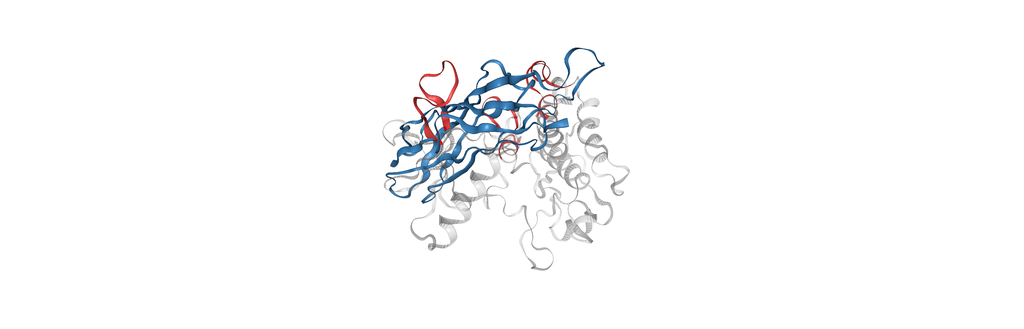

```
Manifest: /workspace/repos/tomo_2026b/md/data/md_calx_3qqu/md_results_manifest.json (saved 2026-08-17T10:10:16.836744+00:00)
```

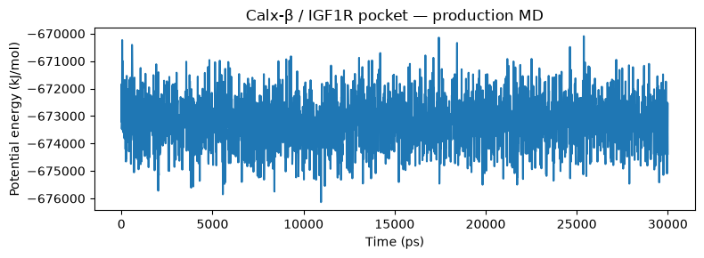

```
True
```

```
Computing binding metrics: 3001 frames, 30000 ps
Saved binding metrics: /workspace/repos/tomo_2026b/md/data/md_calx_3qqu/md_binding_metrics.csv
```

|  | time_ps | ligand_rmsd_nm | receptor_contacts | receptor_contact_residues |
| --- | --- | --- | --- | --- |
| count | 3001.000 | 3001.000 | 3001.000 | 3001.000 |
| mean | 15000.000 | 0.199 | 52.034 | 17.071 |
| std | 8664.584 | 0.016 | 7.991 | 2.318 |
| min | 0.000 | 0.000 | 22.000 | 9.000 |
| 25% | 7500.000 | 0.188 | 48.000 | 16.000 |
| 50% | 15000.000 | 0.199 | 52.000 | 17.000 |
| 75% | 22500.000 | 0.210 | 57.000 | 19.000 |
| max | 30000.000 | 0.251 | 77.000 | 25.000 |

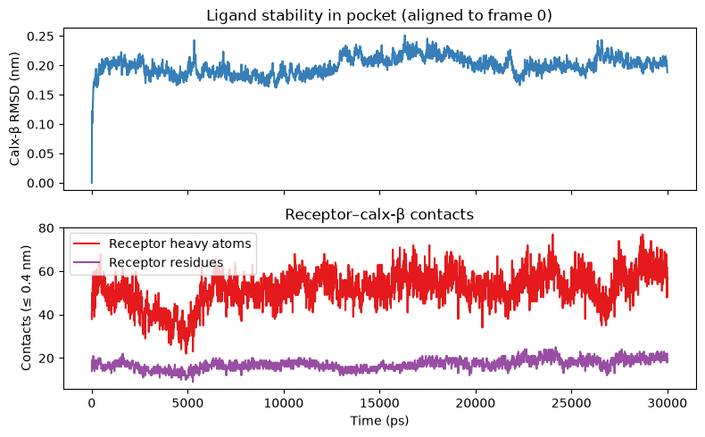

Binding stability assessment (heuristic)

- **Trajectory length:** 30000 ps (3001 frames)

- **Static dock score (Vina):** -18.39 kcal/mol (pose quality only, not MD ΔG)

- **Calx-β RMSD vs t=0:** median 0.20 nm, max 0.25 nm, late−early drift +0.01 nm → **moderately mobile but largely retained**

- **Receptor contacts (≤ 0.4 nm):** median 52 heavy-atom pairs / 17 residues, min 9 residues → Receptor contacts are **persistent** across the run.

**Overall:** The complex appears **relatively stable** over this production run: calx-β stays near the docked pose with sustained pocket contacts. This supports **retained binding** over 30.0 ns, though quantitative affinity still requires MM-PBSA/GBSA or longer sampling.

*Note: These metrics do not equal binding free energy. MM-PBSA/GBSA (or longer sampling toward ~100 ns) would be needed for quantitative affinity.*